# Allele frequencies and Hardy–Weinberg expectations

Population Genetics Practical 2: Observed summaries and a random-union model

## Learning objectives

Count alleles with correct missing-call denominators; distinguish allele frequencies, genotype frequencies and heterozygosity; derive HWE expectations; and explain why a finite-sample departure does not by itself establish disequilibrium or its cause.

Continue from Practical 1. Read alongside the slides on genotype frequencies, allele frequencies and the Hardy–Weinberg law. Use base R; the six hypothetical individuals are not biological study results.

## 1. Count the called genotypes

At our diploid biallelic locus, dosage counts copies of A: 2 means AA, 1 means AB and 0 means BB. The third individual has an unknown genotype.

**Show R code**

```r
dosage <- c(2L,1L,NA_integer_,0L,1L,2L)
called <- dosage[!is.na(dosage)]
stopifnot(length(called)>0L,all(called %in% 0:2))
counts <- c(AA=sum(called==2L),AB=sum(called==1L),BB=sum(called==0L))
n_called <- length(called)
n_missing <- sum(is.na(dosage))
counts
```

```
AA AB BB
 2  2  1
```

**Show R code**

```r
c(called=n_called,missing=n_missing,called_chromosomes=2*n_called)
```

```
            called            missing called_chromosomes
                 5                  1                 10
```

**Question 1.** What is the genotype-frequency denominator? What is the allele-frequency denominator?

**Suggested answer**

Five called individuals give the genotype denominator. Ten called allele copies give the allele denominator. The missing individual contributes neither a known genotype nor known allele copies. Excluding missing calls describes the called sample; it does not prove missingness is ignorable for population inference.

## 2. Calculate observed frequencies and heterozygosity

For called counts $n_{AA},n_{AB},n_{BB}$,

$$\hat p_A=\frac{2n_{AA}+n_{AB}}{2n_c},\qquad
\hat q_B=1-\hat p_A,\qquad H_O=\frac{n_{AB}}{n_c}.$$

No HWE assumption is required for these observed summaries.

**Show R code**

```r
observed <- counts/n_called
p_A <- sum(called)/(2*n_called)
q_B <- 1-p_A
H_observed <- unname(observed["AB"])
knitr::kable(data.frame(genotype=names(counts),count=counts,
                       observed_frequency=observed),digits=3,row.names=FALSE)
```

| genotype | count | observed_frequency |
| --- | --- | --- |
| AA | 2 | 0.4 |
| AB | 2 | 0.4 |
| BB | 1 | 0.2 |

**Show R code**

```r
c(p_A=p_A,q_B=q_B,H_observed=H_observed)
```

```
       p_A        q_B H_observed
       0.6        0.4        0.4
```

**Show R code**

```r
stopifnot(abs(p_A-0.6)<1e-12,abs(H_observed-0.4)<1e-12,
          abs(sum(observed)-1)<1e-12)
```

**Show R code**

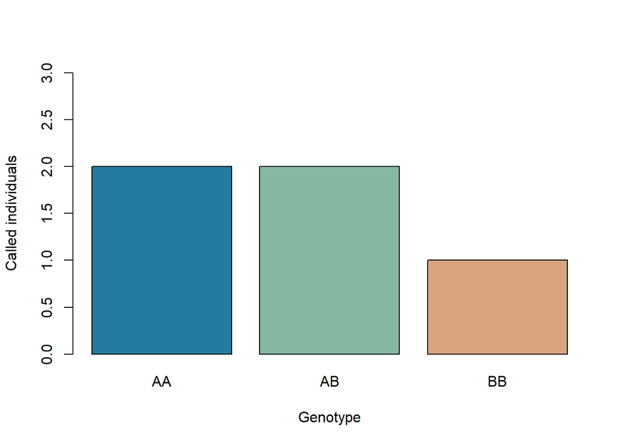

Figure 1: Genotype counts among five called individuals. One missing call is excluded.

```r
barplot(counts,col=c("#247BA0","#86B7A3","#D8A47F"),
        ylab="Called individuals",xlab="Genotype",ylim=c(0,3))
```

**Question 2.** Is the A frequency 0.6 the same quantity as the AA frequency 0.4?

**Suggested answer**

No. Allele frequency counts allele copies, while genotype frequency counts individuals. Two AA individuals contribute four A copies, and two AB individuals contribute two more. Observed heterozygosity is the fraction of called individuals with AB, here 0.4.

### Allele reversal and all-missing loci

**Show R code**

```r
B_dosage <- 2L-dosage
p_B_recounted <- sum(B_dosage,na.rm=TRUE)/(2*n_called)
stopifnot(abs(p_B_recounted-q_B)<1e-12)
p_B_recounted
```

```
[1] 0.4
```

**Show R code**

```r
all_missing <- rep(NA_integer_,4)
called_count <- sum(!is.na(all_missing))
frequency <- if(called_count==0L) NA_real_ else
  sum(all_missing,na.rm=TRUE)/(2*called_count)
frequency
```

```
[1] NA
```

An all-missing locus has no called denominator: its frequency is undefined, not zero. A monomorphic called locus has a defined frequency of zero or one.

## 3. Derive HWE expectations

Assume two independently sampled gametes from one pool, each carrying A with probability $p$ and B with probability $q=1-p$. AA requires A from both gametes, giving $p^2$. AB has two ordered possibilities, A then B or B then A, giving $2pq$. BB has probability $q^2$.

$$f_{AA}=p^2,\qquad f_{AB}=2pq,\qquad f_{BB}=q^2.$$

The proportions sum to $(p+q)^2=1$. This describes genotype formation at supplied frequencies. Stable allele frequencies over generations require additional assumptions about selection, migration, mutation and drift. Random union of gametes does not force a small sample to match its expectations exactly.

**Show R code**

```r
expected <- c(AA=p_A^2,AB=2*p_A*q_B,BB=q_B^2)
expected_counts <- n_called*expected
H_expected <- unname(expected["AB"])
knitr::kable(data.frame(genotype=names(counts),observed_count=counts,
                       observed_proportion=observed,
                       expected_proportion=expected,
                       expected_count=expected_counts),digits=3,row.names=FALSE)
```

| genotype | observed_count | observed_proportion | expected_proportion | expected_count |
| --- | --- | --- | --- | --- |
| AA | 2 | 0.4 | 0.36 | 1.8 |
| AB | 2 | 0.4 | 0.48 | 2.4 |
| BB | 1 | 0.2 | 0.16 | 0.8 |

**Show R code**

```r
stopifnot(max(abs(expected-c(AA=.36,AB=.48,BB=.16)))<1e-12)
```

**Question 3.** Why can expected counts be fractional? Should we round them to obtain the model’s predicted sample?

**Suggested answer**

Expected counts are averages over possible samples, not a particular realized sample. Here they are 1.8, 2.4 and 0.8. Rounding them would replace the model expectation with arbitrary integers.

**Show R code**

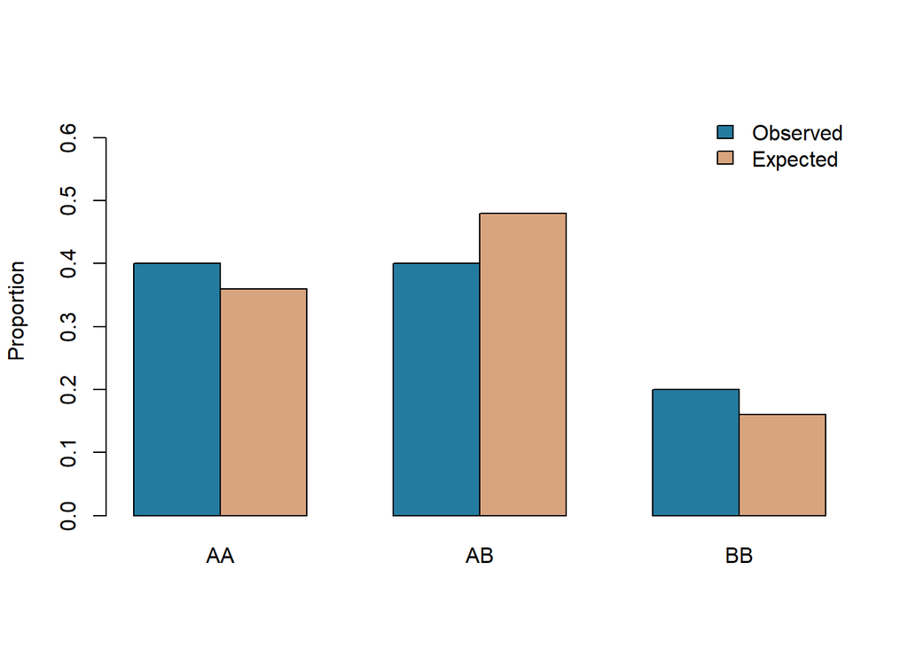

Figure 2: Observed genotype proportions compared with HWE expectations at the sample’s estimated A frequency.

```r
barplot(rbind(Observed=observed,Expected=expected),beside=TRUE,
        col=c("#247BA0","#D8A47F"),ylim=c(0,0.65),ylab="Proportion")
legend("topright",c("Observed","Expected"),
       fill=c("#247BA0","#D8A47F"),bty="n")
```

Observed heterozygosity is 0.4; plug-in expected heterozygosity is 0.48. The same sample supplied both its allele-frequency estimate and observed counts. Their difference is descriptive, not automatically a calibrated test statistic or an inbreeding estimate.

## 4. Explore the role of allele frequency

**Show R code**

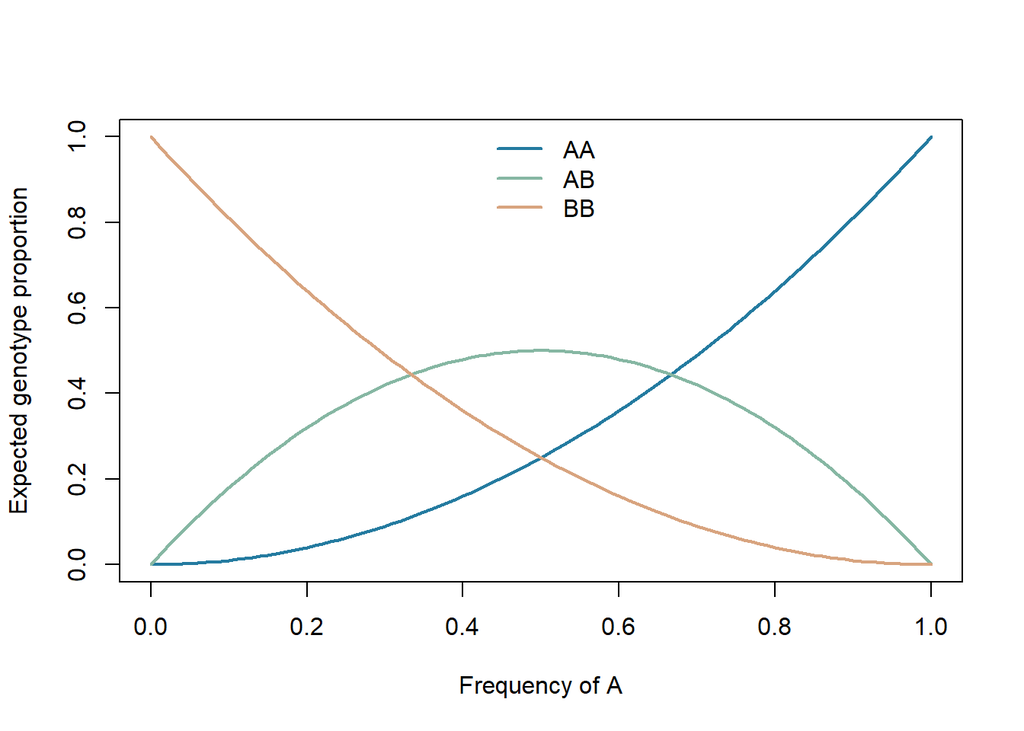

Figure 3: HWE genotype expectations across supplied A frequencies. Heterozygosity is maximal when both alleles have frequency one half.

```r
p_grid <- seq(0,1,length.out=101)
curves <- cbind(AA=p_grid^2,AB=2*p_grid*(1-p_grid),BB=(1-p_grid)^2)
matplot(p_grid,curves,type="l",lty=1,lwd=2,
        col=c("#247BA0","#86B7A3","#D8A47F"),
        xlab="Frequency of A",ylab="Expected genotype proportion")
legend("top",colnames(curves),lty=1,lwd=2,
       col=c("#247BA0","#86B7A3","#D8A47F"),bty="n")
```

**Question 4.** Why is $H_E=2p(1-p)$ zero at fixation and maximal at $p=0.5$?

**Suggested answer**

At fixation only one allele is present, so different alleles cannot pair. Since $2p(1-p)=0.5-2(p-0.5)^2$, its maximum is 0.5 at equal allele frequencies. This describes random pairing; an observed sample or a nonrandom mating system need not have heterozygosity at most 0.5.

## 5. Separate expectation from a finite realization

Draw 20 small samples of five genotypes from the fixed model proportions. This is a seeded toy sampling calculation, not a simulated biological population or an HWE test.

**Show R code**

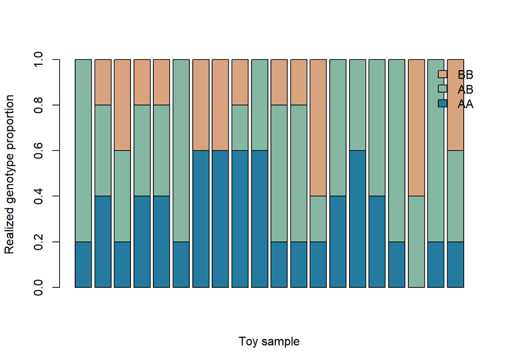

Figure 4: Twenty possible five-individual samples from the fixed HWE model at p(A)=0.6. Finite genotype proportions vary.

```r
set.seed(20261008)
samples <- rmultinom(20,size=n_called,prob=expected)
stopifnot(all(colSums(samples)==n_called))
barplot(samples/n_called,col=c("#247BA0","#86B7A3","#D8A47F"),
        xlab="Toy sample",ylab="Realized genotype proportion",
        legend.text=rownames(samples),args.legend=list(x="topright",bty="n"))
```

**Question 5.** Does a heterozygote deficit in one sample prove inbreeding?

**Suggested answer**

No. Finite sampling, population mixtures, relatives, nonrandom mating or genotype errors can affect the comparison. Formal assessment requires a declared sampling model and a suitable test. Expected counts in this five-individual example are too small for an automatic large-sample chi-squared approximation. This practical does not conduct an HWE test or identify a cause of departure.

## Exercises

1. Replace the missing genotype with AB. Recalculate allele frequency and observed heterozygosity.
2. Set every called genotype to AA. What happens to observed and expected heterozygosity?
3. Reverse A and B in the HWE model. Which proportions change?
4. Compare two equally weighted populations, one with $p_A=0.9$ and the other with $p_A=0.1$, each under HWE. Is pooled heterozygosity equal to the HWE expectation at the pooled frequency?

**Suggested solutions**

**Show R code**

```r
completed <- dosage
completed[is.na(completed)] <- 1L
c(p_A=mean(completed)/2,H_observed=mean(completed==1L))
```

```
       p_A H_observed
 0.5833333  0.5000000
```

**Show R code**

```r
stopifnot(abs(mean(completed)/2-7/12)<1e-12,
          mean(completed==1L)==0.5)
fixed <- rep(2L,n_called)
c(p_A=mean(fixed)/2,H_observed=mean(fixed==1L),
  H_expected=2*(mean(fixed)/2)*(1-mean(fixed)/2))
```

```
       p_A H_observed H_expected
         1          0          0
```

**Show R code**

```r
reversed_expected <- c(AA=q_B^2,AB=2*p_A*q_B,BB=p_A^2)
reversed_expected
```

```
  AA   AB   BB
0.16 0.48 0.36
```

**Show R code**

```r
subpopulation_p <- c(0.9,0.1)
p_pool <- mean(subpopulation_p)
H_within <- mean(2*subpopulation_p*(1-subpopulation_p))
H_pool_model <- 2*p_pool*(1-p_pool)
c(pooled_p_A=p_pool,within_population_H=H_within,
  pooled_HWE_model_H=H_pool_model)
```

```
         pooled_p_A within_population_H  pooled_HWE_model_H
               0.50                0.18                0.50
```

**Show R code**

```r
stopifnot(abs(H_within-.18)<1e-12,abs(H_pool_model-.5)<1e-12)
```

The completed sample has $p_A=7/12$ and $H_O=0.5$. Fixation gives both heterozygosities zero. Allele reversal exchanges the homozygote proportions. The mixture retains within-population heterozygosity 0.18 while pooled HWE predicts 0.5; this is a Wahlund-effect illustration, not proof of pedigree inbreeding. Pooling groups does not create random mating between them.

## Package and app connections

The corresponding [gpop examples](https://github.com/psoerensen/gpop/tree/main/inst/examples) use the same five-called-individual calculation. They are base-R teaching scripts, not exported scientific functions. If gpop is already installed, its examples can be inspected independently:

**Show R code**

```r
example_file <- system.file("examples","allele_frequencies.R",
                            package="gpop",mustWork=TRUE)
example_environment <- new.env()
sys.source(example_file,envir=example_environment)
example_environment$reference
```

For optional local exploration, the existing Gene Pool and Hardy–Weinberg Explorer and random-mating simulator provide Shiny interfaces. They require their existing Shiny/ggplot2 dependencies and are not deployed web apps. This tutorial does not change or qualify their implementations.

## Connection to the next topic

Next distinguish population structure, nonrandom mating and inbreeding, then study diversity and evolutionary forces. The central distinction remains: observed counts summarize data; expectations state a model; estimators and tests require additional assumptions.